# Création de cartes choroplèthes avec ggplot2

# 3 Création d’une belle carte choroplèthe avec {ggplot2}

## 3.1 Utilisation de la variable de remplissage (c’est-à-dire la variable attributaire)

Pour afficher le nombre de cas, par exemple pour l’année 2021, nous devons remplir les polygones dessinés avec `geom_sf()` en utilisant la variable `fill`. Cela est très simple car il suit la même logique que la syntaxe du package {ggplot2}.

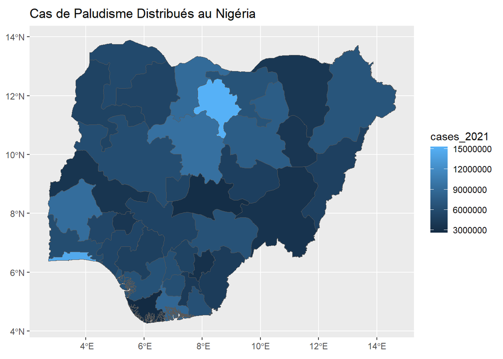

```r
ggplot(data=malaria2) +
  geom_sf(aes(fill=cases_2021)) +   # définir le remplissage en fonction de la variable de comptage des cas
  labs(title = "Cas de Paludisme Distribués au Nigéria")
```

Nous créons une carte choroplèthe de base à l’aide de {ggplot2}. L’esthétique `fill` est définie pour varier en fonction de la variable `cases`, ce qui colore les régions en fonction du nombre de cas de paludisme.

## 3.2 Personnalisation de la carte

Nous pouvons personnaliser la carte en ajoutant des titres aux axes et à la légende, en ajoutant une flèche indiquant le nord et une échelle à l’aide de `ggspatial::annotation_north_arrow()` et `ggspatial::annotation_scale()`, et en changeant le thème en `theme_bw()`.

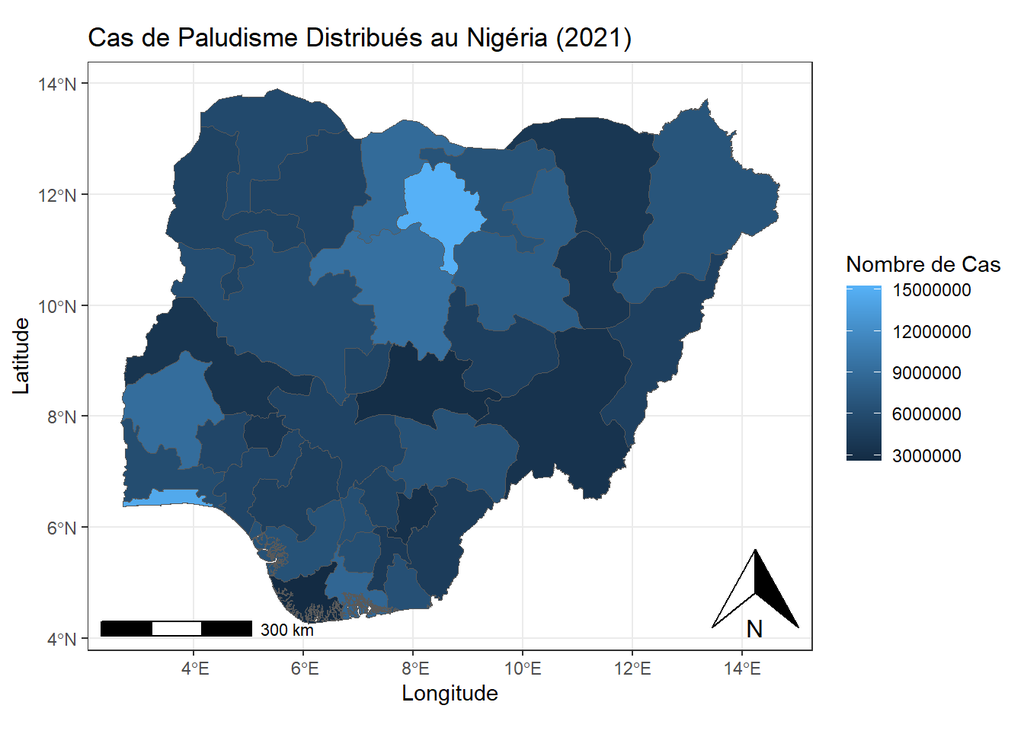

```r
ggplot(data=malaria2) +
  geom_sf(aes(fill=cases_2021)) +   # définir le remplissage en fonction de la variable de comptage des cas
  labs(title = "Cas de Paludisme Distribués au Nigéria (2021)",
       fill = "Nombre de Cas") +
  xlab("Longitude")+
  ylab("Latitude")+
  ggspatial::annotation_north_arrow(location = "br")+
  ggspatial::annotation_scale(location = "bl")+
  theme_bw()
```

Dans cette section, nous avons d’abord créé une carte choroplèthe de base à l’aide de {ggplot2} pour visualiser les cas de paludisme régionaux au Nigéria pour 2021. Ensuite, nous avons amélioré la carte en ajoutant des `titres`, des `étiquettes d'axes`, une `flèche indiquant le nord`, une `échelle`, et en appliquant un `thème monochrome`.

# 4 Échelle des couleurs

## 4.1 Échelle des couleurs pour les attributs continus

La fonction `scale_fill_continuous()` du package {ggplot2} en R est utilisée pour appliquer une échelle de couleurs continue à une carte choroplèthe.

Nous pouvons personnaliser la palette de couleurs utilisée pour l’échelle de couleurs continues en spécifiant les paramètres `low` et `high` dans la fonction `scale_fill_continuous()`.

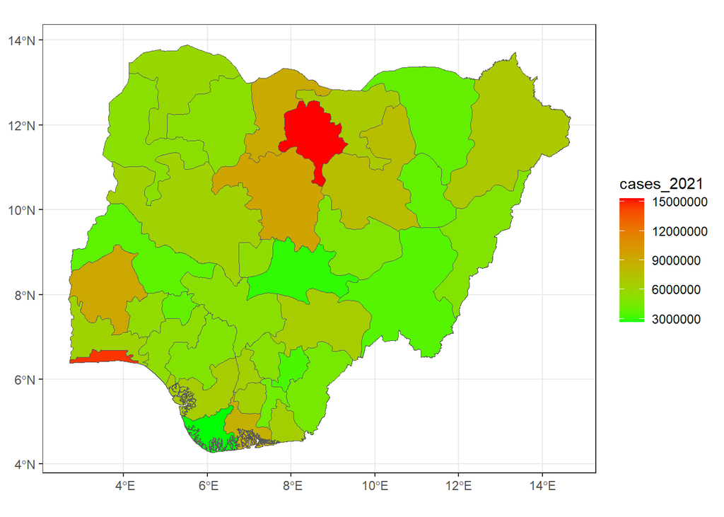

```r
# Créer un objet ggplot
ggplot(data = malaria2) +
  geom_sf(aes(fill = cases_2021)) +
  scale_fill_continuous(low = "green", high = "red") + # appliquer une échelle de couleurs continue
  theme_bw()
```

Dans cette section, nous avons appris comment appliquer une échelle de couleurs continue à une carte choroplèthe à l’aide de la fonction `scale_fill_continuous()` du package {ggplot2} en R et comment personnaliser la palette de couleurs.